# Notes on Chapter 12

The Caveman Coder

2026-01-03

# Building a dashboard to visualize spatial data with **flexdashboard**

Dashboards are tools for effective data visualization that help communicate information in an intuitive and insightful manner,and are essential to support data-driven decision making.

## The R package **flexdashboard**

Brief review of R Markdown…

### R Markdown

- allows easy work reproducibility by including R code that generates results, and narrative text explaining the work.

When the Markdown file is complied, the R code is executed and the results are appended to a report that can take a variety of formats including HTML and PDF.

### Dashboard components

A flexdashboard can include these components: - Interactive JavaScript data visualizations based on HTML widgets  
- Charts created with standard R graphics  
- Simple tables created with `knitr::kable()`  
- Interactive tables created with the **DT** package  
- Value boxes created with the `valueBox()` function  
- Gauges that display values on a meter  
- Text, images, and equations  
- Navigation bar with links to source code, websites, and other tools related to the dashboard.

## A dashboard to visualize global air pollution

### Data

Map data for this exercise come from **rnaturalearth**.

```r
library(sf)
```

```r
library(rnaturalearth)

map <- ne_countries(returnclass = "sf")
names(map)[names(map) == "iso_a3"] <- "ISO3"
names(map)[names(map) == "name"] <- "NAME"

head(map)
```

```
## Simple feature collection with 6 features and 168 fields
## Geometry type: MULTIPOLYGON
## Dimension:     XY
## Bounding box:  xmin: -180 ymin: -18.28799 xmax: 180 ymax: 83.23324
## Geodetic CRS:  WGS 84
##        featurecla scalerank labelrank                  sovereignt sov_a3
## 1 Admin-0 country         1         6                        Fiji    FJI
## 2 Admin-0 country         1         3 United Republic of Tanzania    TZA
## 3 Admin-0 country         1         7              Western Sahara    SAH
## 4 Admin-0 country         1         2                      Canada    CAN
## 5 Admin-0 country         1         2    United States of America    US1
## 6 Admin-0 country         1         3                  Kazakhstan    KA1
##   adm0_dif level              type tlc                       admin adm0_a3
## 1        0     2 Sovereign country   1                        Fiji     FJI
## 2        0     2 Sovereign country   1 United Republic of Tanzania     TZA
```

[output cut: 207 more lines]

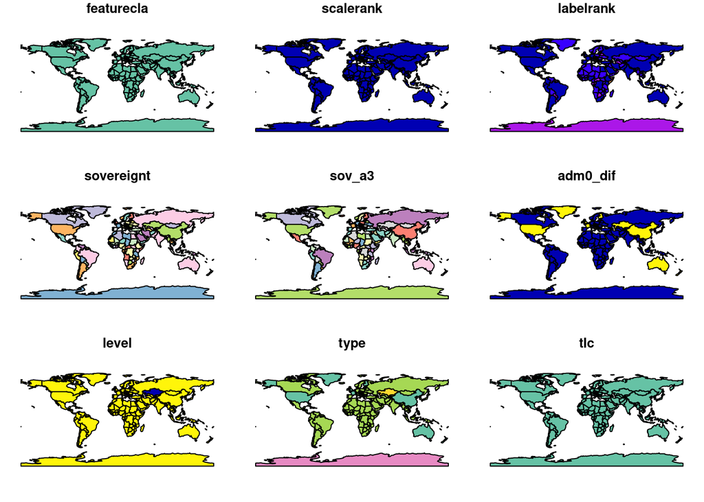

World map obtained from the **rnaturalearth** package.

```r
plot(map)
```

Obtaining $PM_{2.5}$ concentration levels from the **wbstats** package:

```r
library(wbstats)
indicators <- wb_search(pattern = "pollution")

head(indicators)
```

```
## # A tibble: 6 × 3
##   indicator_id         indicator                                  indicator_desc
##   <chr>                <chr>                                      <chr>
## 1 EN.ATM.PM25.MC.M3    PM2.5 air pollution, mean annual exposure… Population-we…
## 2 EN.ATM.PM25.MC.T1.ZS PM2.5 pollution, population exposed to le… Percent of po…
## 3 EN.ATM.PM25.MC.T2.ZS PM2.5 pollution, population exposed to le… Percent of po…
## 4 EN.ATM.PM25.MC.T3.ZS PM2.5 pollution, population exposed to le… Percent of po…
## 5 EN.ATM.PM25.MC.ZS    PM2.5 air pollution, population exposed t… Percent of po…
## 6 IQ.CPA.ENVR.XQ       CPIA policy and institutions for environm… Policy and in…
```

Downloading the 2016 data whose `indicator_id` is `EN.ATM.PM25.MC.M3` using the `wb_data()` function:

```r
d <- wb_data(
  indicator = "EN.ATM.PM25.MC.M3",
  start_date = 2016,
  end_date = 2016
)

head(d)
```

```
## # A tibble: 6 × 9
##   iso2c iso3c country           date EN.ATM.PM25.MC.M3 unit  obs_status footnote
##   <chr> <chr> <chr>            <dbl>             <dbl> <chr> <chr>      <chr>
## 1 AW    ABW   Aruba             2016              NA   <NA>  <NA>       <NA>
## 2 AF    AFG   Afghanistan       2016              72.8 <NA>  <NA>       <NA>
## 3 AO    AGO   Angola            2016              25.2 <NA>  <NA>       <NA>
## 4 AL    ALB   Albania           2016              17.6 <NA>  <NA>       <NA>
## 5 AD    AND   Andorra           2016              10.1 <NA>  <NA>       <NA>
## 6 AE    ARE   United Arab Emi…  2016              43.1 <NA>  <NA>       <NA>
## # ℹ 1 more variable: last_updated <date>
```

Assigning the $PM_{2.5}$ readings from `d` to `map` where the country matches, using the `match()` function:

```r
map$PM2.5 <- d[match(map$ISO3, d$iso3c), ]$EN.ATM.PM25.MC.M3
head(map)
```

```
## Simple feature collection with 6 features and 169 fields
## Geometry type: MULTIPOLYGON
## Dimension:     XY
## Bounding box:  xmin: -180 ymin: -18.28799 xmax: 180 ymax: 83.23324
## Geodetic CRS:  WGS 84
##        featurecla scalerank labelrank                  sovereignt sov_a3
## 1 Admin-0 country         1         6                        Fiji    FJI
## 2 Admin-0 country         1         3 United Republic of Tanzania    TZA
## 3 Admin-0 country         1         7              Western Sahara    SAH
## 4 Admin-0 country         1         2                      Canada    CAN
## 5 Admin-0 country         1         2    United States of America    US1
## 6 Admin-0 country         1         3                  Kazakhstan    KA1
##   adm0_dif level              type tlc                       admin adm0_a3
## 1        0     2 Sovereign country   1                        Fiji     FJI
## 2        0     2 Sovereign country   1 United Republic of Tanzania     TZA
```

[output cut: 207 more lines]

### Table using **DT**

Creating an interactive table using the `datatable()` function from the **DT** package:

```r
library(DT)

DT::datatable(
  map[, c("ISO3", "NAME", "PM2.5")],
  rownames = FALSE,
  options = list(pageLength = 10)
)
```

| ISO3 | NAME | PM2.5 | geometry |
| --- | --- | --- | --- |
| FJI | Fiji | 12.3284242671983 | {'type': 'MultiPolygon', 'coordinates': [[[[180, -16.06713266364245], [180, -16.5552165666392], [179.3641426619641, -16.80135407694688], [178.7250593629971, -17.01204167436804], [178.5968385951171, -1… |
| TZA | Tanzania | 25.3938175391915 | {'type': 'MultiPolygon', 'coordinates': [[[[33.90371119710453, -0.9500000000000001], [34.07261999999997, -1.059819999999945], [37.69868999999994, -3.096989999999948], [37.7669, -3.67712], [39.20222, -… |
| ESH | W. Sahara |  | {'type': 'MultiPolygon', 'coordinates': [[[[-8.665589565454809, 27.65642588959236], [-8.665124477564191, 27.58947907155823], [-8.684399786809053, 27.39574412689601], [-8.6872936670174, 25.881056219988… |
| CAN | Canada | 6.40675155079521 | {'type': 'MultiPolygon', 'coordinates': [[[[-122.84, 49.00000000000011], [-122.97421, 49.00253777777778], [-124.91024, 49.98456], [-125.62461, 50.41656], [-127.43561, 50.83061], [-127.99276, 51.71583]… |
| USA | United States of America | 7.40835009300858 | {'type': 'MultiPolygon', 'coordinates': [[[[-122.84, 49.00000000000011], [-120, 49.00000000000011], [-117.03121, 49], [-116.04818, 49], [-113, 49], [-110.05, 49], [-107.05, 49], [-104.04826, 48.999860… |
| KAZ | Kazakhstan | 22.7637525232887 | {'type': 'MultiPolygon', 'coordinates': [[[[87.35997033076265, 49.21498078062912], [86.59877648310336, 48.54918162698063], [85.7682328633083, 48.45575063739699], [85.72048383987067, 47.45296946877311]… |
| UZB | Uzbekistan | 37.5481850195136 | {'type': 'MultiPolygon', 'coordinates': [[[[55.96819135928291, 41.30864166926936], [55.9289172707411, 44.99585846615911], [58.50312706892845, 45.58680430763297], [58.68998904809581, 45.50001373959873]… |
| PNG | Papua New Guinea | 16.1543562654462 | {'type': 'MultiPolygon', 'coordinates': [[[[141.0002104025918, -2.60015105551566], [142.7352466167915, -3.28915292726321], [144.5839709820332, -3.861417738463416], [145.27317955951, -4.373737888205049… |
| IDN | Indonesia | 19.1310042759597 | {'type': 'MultiPolygon', 'coordinates': [[[[141.0002104025918, -2.60015105551566], [141.017056919519, -5.859021905138071], [141.0338517600138, -9.117892754760483], [140.1434151551925, -8.2971676571009… |
| ARG | Argentina | 14.2700594540808 | {'type': 'MultiPolygon', 'coordinates': [[[[-68.63401022758323, -52.63637045887449], [-68.25, -53.1], [-67.75, -53.85], [-66.45, -54.45], [-65.05, -54.7], [-65.5, -55.2], [-66.45, -55.25], [-66.959920… |

[output cut: 167 more lines]

Table with the $PM_{2.5}$ values.

### Map using **leaflet**

Creating an interactive map using **leaflet**:

```r
library(leaflet)

pal <- colorBin(
  palette = "viridis", domain = map$PM2.5,
  bins = seq(0, max(map$PM2.5, na.rm = TRUE) + 10, by = 10)
)


map$labels <- paste0(
  "<strong> Country: </strong> ",
  map$NAME, "<br/> ",
  "<strong> PM2.5: </strong> ",
  map$PM2.5, "<br/> "
) %>%
  lapply(htmltools::HTML)

leaflet(map) |>
  addTiles() |>
  setView(lng = 0, lat = 30, zoom = 2) |>
  addPolygons(
    fillColor = ~ pal(PM2.5),
    color = "white",
    fillOpacity = 0.7,
    label = ~labels,
    highlight = highlightOptions(
      color = "black",
      bringToFront = TRUE
    )
  ) |>
  leaflet::addLegend(
    pal = pal, values = ~PM2.5,
    opacity = 0.7, title = "PM2.5"
  )
```

[interactive chart not shown]

Leaflet map with the $PM_{2.5}$ values.

### Histogram using **ggplot2**

Creating a histogram with the $PM_{2.5}$ values using `ggplot()`:

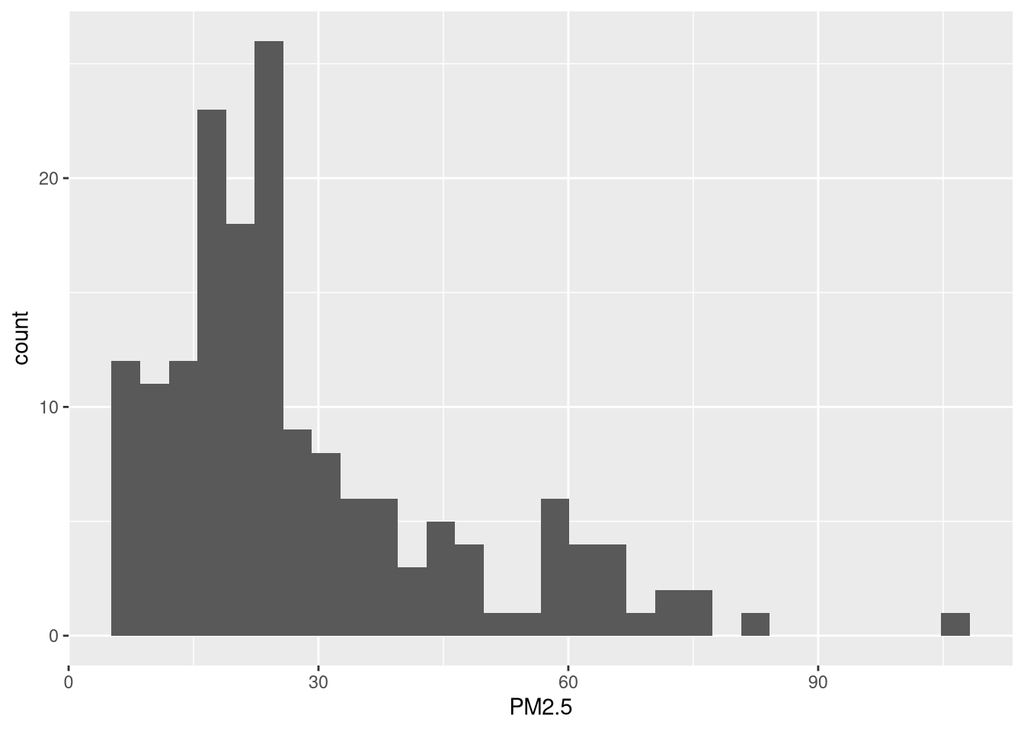

Histogram of the $PM_{2.5}$ values.

```r
library(ggplot2)

map |> ggplot(
  aes(x = PM2.5)
) +
  geom_histogram()
```

### R Markdown structure. YAML header and layout

In the YAML header, we should specify the desired title and the output (`flexdashboard::flex_dashboard`) in this case. Columns are specified using `--------------------`. The components to be included are specified by using `###`. Column width can be specified as 600 pixels using `Column {data-width=600}`. Paste the desired R code below the column name.